# 05.Gene function analysis

**5.1 Gene Ontology (GO) enrichment of genes with differential coverages between preterm and full-term pregnancies.**

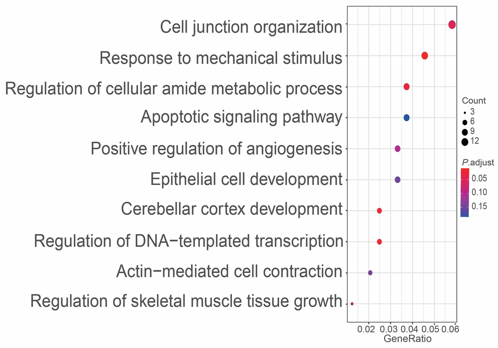

GO enrichment analysis was implemented using Metascape (ver. 20220101) and the result was plotted using ggplot2.

**5.2 KEGG pathway enrichment of genes with differential coverage between preterm and full-term pregnancies.**

```r
library(DOSE)
library(org.Hs.eg.db)
library(topGO)
library(clusterProfiler)
library(pathview)
library(ggplot2)
library(tidyverse)
```

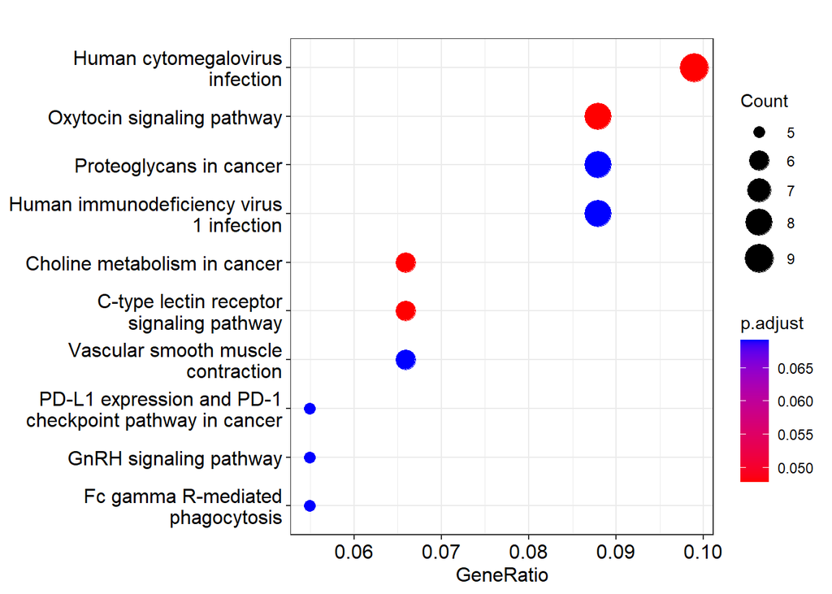

```r
load("Preterm.RData")
data <- x08
test1 = bitr(data[,1], fromType="SYMBOL", toType=c("ENSEMBL", "ENTREZID"), OrgDb="org.Hs.eg.db")

m <- enrichKEGG(test1$ENTREZID, organism = "hsa", keyType = "kegg", pvalueCutoff = 0.2,pAdjustMethod = "fdr", minGSSize = 10, maxGSSize = 500,qvalueCutoff = 0.2, use_internal_data = FALSE)
dotplot(m,orderBy = "x")
```

KEGG pathway enrichment analysis was implemented using clusterProfiler (ver. 3.18.1).

**5.3 Gene correlation network for transcripts with differential coverage between preterm and full-term pregnancies.**

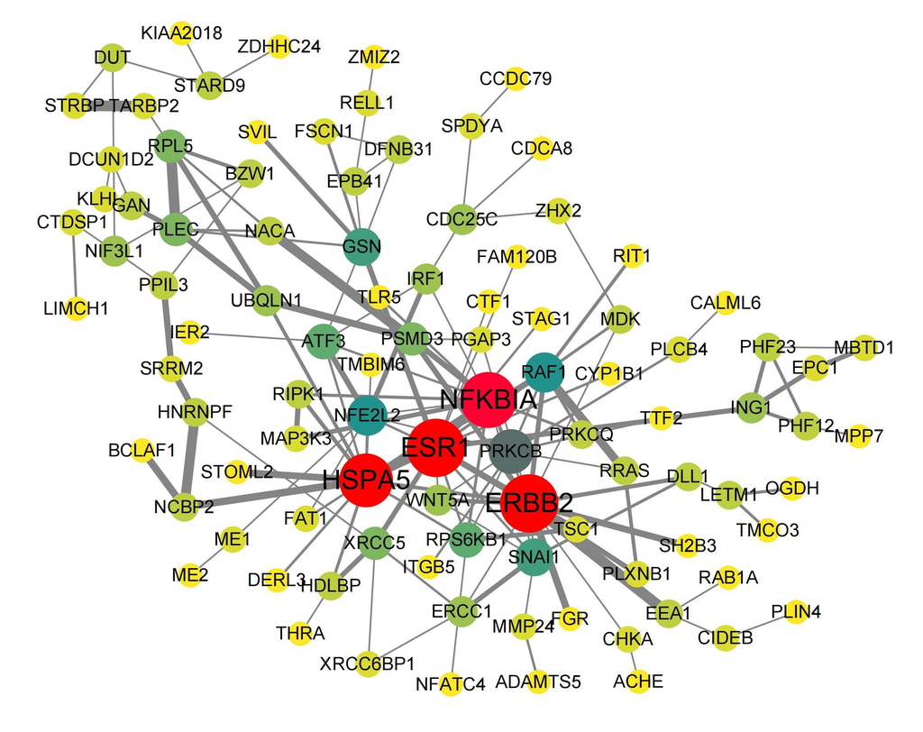

Gene correlation was evaluated using the String database (ver. 11.5) and network visualization was implemented using Cytoscape (ver.3.8).

**5.4 Degrees and heatmap of hub genes interconnection within the correlation network.**

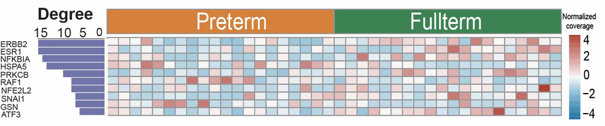

The hub genes of network were analyzed using Cytohubba of Cytoscape. The degree represents the importance of the genes in the network evaluated by cytohubba (ver. 0.1). Top 10 hub genes were selected to plot the heatmap.

**5.5 Correlation network of the hub genes.**

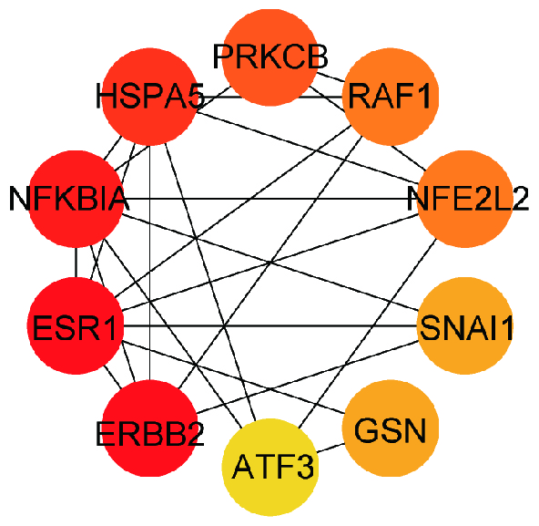

The network of the top 10 hub genes was plotted using Cytoscape.